# The Standard Normal Distribution (N(0,1)) and Z-scores

## Site I

95% of the Martians at Site I ($\mu$ = 200 $\sigma$ = 6) are expected to have a height between 188.24, 211.76

## Site II

95% of the Martians at Site II ($\mu$ = 210 $\sigma$ = 1) are expected to have a height between 208.04, 211.96

## Diagram

“one value, two curves” - One country, two policies

Plotting the Mystery Martian:

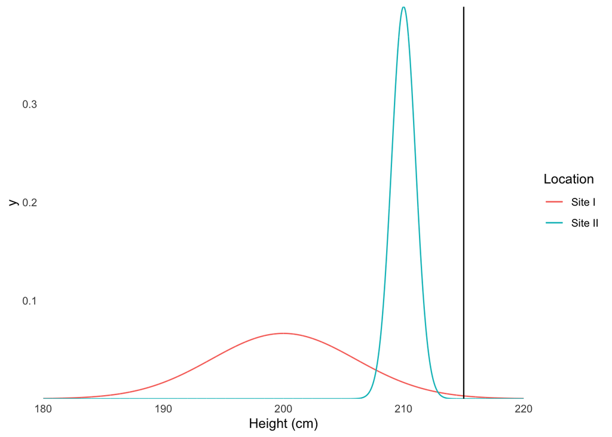

## Calculating Z-scores

### Site I

Calculating Z–scores for the Martian height at site I.

| $x_i (cm)$ | 182 | 188 | 194 | 200 | 206 | 212 | 218 |
| --- | --- | --- | --- | --- | --- | --- | --- |
| $x_i - \mu$ | -18 | -12 | -6 | 0 | 6 | 12 | 18 |
| $z_i$ | -3 | -2 | -1 | 0 | 1 | 2 | 3 |

The Z–score for the Mystery martian at site I is: (215 - 200)/6 = 2.5.

### Site II

Calculating Z–scores for the Martian height at Site II

| $x_i (cm)$ | 207 | 208 | 209 | 210 | 211 | 212 | 213 |
| --- | --- | --- | --- | --- | --- | --- | --- |
| $x_i - \mu$ | -3 | -2 | -1 | 0 | 1 | 2 | 3 |
| $z_i$ | -3 | -2 | -1 | 0 | 1 | 2 | 3 |

The Z–score for the Mystery martian at site II is: (215 - 210)/1 = 5.

Z–scores are a *standardized* score that tells us how many standard deviations (i.e. $\sigma$) any given value $x_i$ is away from the mean (i.e. $\mu$).

## The Standard Normal Distribution

Z–Scores are described by the Standard Normal Distribution, N($\mu$ = 0, $\sigma$ = 1). Thus an *extreme* value is outside the interval [-1.96, 1.96] since values outside this range are less than 5% likely to be observed?

Z–Scores are our first experience with one of the most important equations in all of statistics: **signal:noise**. Here, signal: $x_i - \mu$, noise: $\sigma$.

“one curve, two values” - Lord of the rings model “One curve to rule them all”.

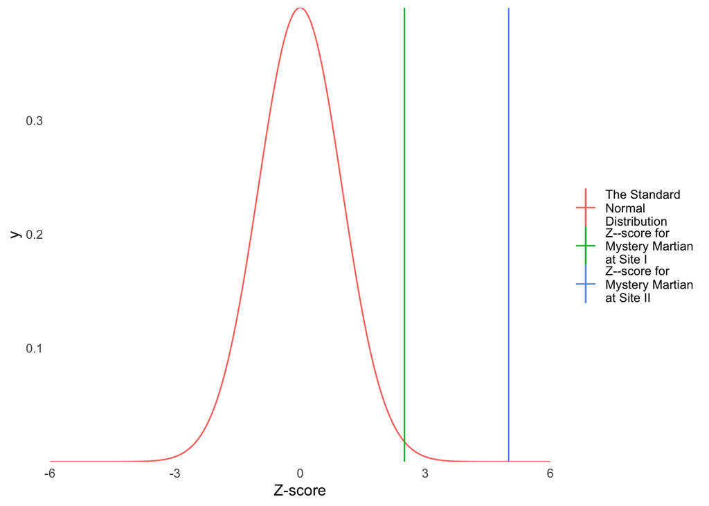